# Allgmeine Hinweise zur Website und zum Programm (Im Aufbau)

Methodik

Autor:innen

Zugehörigkeit

Toni Wöhrl

Universität Erfurt

Florian Bähr

Universität Erfurt

Veröffentlichungsdatum

20. Mai 2026

Geändert

23. September 2026

## Einordnung des Programms

Die auf dieser Website zusammengetragenen Information stehen im Kontext des Programms „BEWEGTE KINDER = GESÜNDERE KINDER“ BeKiGeKi. Das Programm ist als **langfristig angelegte Kooperationsstruktur** zwischen Schule, organisiertem Sport und Wissenschaft konzipiert und verbindet **praktische Bewegungsförderung**, standardisierte motorische Erhebungen (Bewegungs-Checks) sowie **datengestützte Rückmeldungen**. Diese Rückmeldungen richten sich an verschiedene Ebenen des Bildungssystems, an Politik und organisierten Sport sowie an Kinder, Sorgeberechtigte und eine interessierte Öffentlichkeit.

Die Durchführung des Programms erfolgt nicht in einem statischen, sondern in einem fortlaufend weiterentwickelten Rahmen. Erfahrungen aus dem Schulalltag, Rückmeldungen von Eltern, Perspektiven des organisierten Sports sowie wissenschaftliche Anforderungen fließen fortlaufend in die Weiterentwicklung der Abläufe, Erhebungsinstrumente und Auswertungslogiken ein. Die dabei entstehenden Lösungen sind daher in vielen Bereichen bewusst als **fachlich und organisatorisch abgestimmte Kompromisse** zu verstehen, die sowohl praktischen als auch wissenschaftlichen Anforderungen gerecht werden sollen.

## Ziel dieser Website

Diese Website dient einerseits als **Arbeits- und Dokumentationsumgebung**, in der Versionen, Zwischenstände und Entwicklungen der einzelnen Jahre archiviert, nachvollzogen und zusammengeführt werden. Andererseits werden Daten und Auswertungen über mehrere Jahre hinweg aggregiert, harmonisiert und in einer Form präsentiert, die historische Entwicklungen sichtbar macht und den Vergleich über Kohorten und Berichtsjahre hinweg erleichtert.

Die hier bereitgestellten Inhalte sind daher nicht ausschließlich als abgeschlossene Endprodukte zu verstehen. Vielmehr bilden sie einen Arbeitsstand in einem **Entwicklungsprozess** ab, in dem Dokumentation, Archivierung, Auswertung und Präsentation eng miteinander verbunden sind.

## Erhebung und Datenfluss

Die Bewegungs-Checks wurden in den Schuljahren 2017/18 bis 2021/22 **freiwillig** und seit dem Schuljahr 2022/23 **verbindlich** in einem festgelegten Testzeitraum in den dritten Klassen Thüringer Grundschulen durchgeführt. Die Testabnahme erfolgt durch Lehrkräfte vor Ort; die Schulen erfassen die erhobenen Werte in standardisierten Excel-Dateien und übermitteln diese **anonymisiert** zur weiteren Verarbeitung und Auswertung an die Universität Erfurt.

Neben anonymisierten motorischen **Testwerten** können auch anonymisierte, freiwillige Angaben aus **Fragebögen** in die Datengrundlage eingehen (z.B. zur Mitgliedschaft in einem Sportverein oder zu Körpergröße und -masse). Diese freiwilligen Angaben und Testteilnahmen sind aufgrund ihrer Erhebungsform grundsätzlich vorsichtig zu interpretieren.

Die Datenerhebung und Datenweiterverarbeitung folgen dem Grundsatz, nur solche Informationen zu verarbeiten, die für bestimmte Auswertungen oder Fragestellungen, Rückmeldungen und die Steuerung des Programms erforderlich sind. Genauere Hinweise zur jeweils verwendeten Auswertungsmethodik finden sich gegebenenfalls auf den entsprechenden Unterseiten.

Der grobe Datenfluss lässt sich wie folgt beschreiben:

1. **Messung und Eintragung an der Schule**: Motorische Tests werden an Schulen durchgeführt und in standardisierten Excel-Dateien dokumentiert.
2. **Übermittlung an die Universität Erfurt**: Die erfassten Dateien werden zur weiteren Aufbereitung, Prüfung und Auswertung an die Universität Erfurt anonymisiert übermittelt.
3. **Deduplizierung und Auswertung**: Eingehende Dateien werden zusammengeführt, auf Dubletten geprüft, in einen auswertbaren Datenstand überführt und für verschiedene Berichtsebenen verarbeitet.
4. **Erstellung von Rückmeldungen**: Auf dieser Grundlage werden PDF-Auswertungen auf Schüler-, Schul- und Kreisebene erzeugt.
5. **Druck und Rückführung in die Praxis**: Die Auswertungen werden in der Landesdruckerei gedruckt, über den organisierten Sport an die Schulen übermittelt, von Lehrkräften verteilt und so an das Elternhaus zurückgeführt.
6. **Archivierung, Verknüpfung und Präsentation:** Die aufbereiteten Daten werden auf dieser Website archiviert, visualisiert und für wissenschaftliche Publikationen mit weiteren Datenquellen (z.B. der Schulstatistik Thüringen, dem Indikatoren- und Kartendienst INKAR zur Raum- und Stadtentwicklung sowie – bundeslandübergreifend – EMOTIKON) verknüpft. Die so entstehenden Darstellungen dienen Schulen, organisiertem Sport, Wissenschaft, Politik und einer interessierten Öffentlichkeit als Instrument unter anderem zur Beobachtung und Weiterentwicklung von Bewegungsförderung.
7. Nutzung und Wirkebenen: Auf Basis der Rückmeldungen und Darstellungen können im Wohnumfeld, in Schulen, im organisierten Sport, bei Schulinstanzen, in Politik/Gesellschaft und in der Wissenschaft Maßnahmen angestoßen, weiterentwickelt oder evaluiert werden.

## Hinweise zur Interpretation der Ergebnisse

Da das Programm in einem **realen schulischen Umfeld** umgesetzt wird, entstehen die Daten nicht unter Laborbedingungen. Unterschiede in Eingabepraxis, Datenvollständigkeit, Dateistrukturen, Maskenversionen und lokalen Abläufen sind deshalb Teil der praktischen Realität und müssen in der Datenaufbereitung berücksichtigt werden. Die Aufbereitung dient der Herstellung eines über Jahre hinweg möglichst konsistenten und interpretierbaren Datenbestands.

Gleichzeitig kann sich die Auswertungsgrundlage je nach Darstellung unterscheiden. Je nach Jahr, Fragestellung, verfügbarer Datenqualität, Vollständigkeit oder Harmonisierungsschritt kann sich die Menge der berücksichtigten Fälle ändern. Nicht jede Abbildung basiert daher notwendigerweise auf exakt derselben Datenbasis.

Diese Website macht auf solche Unterschiede aufmerksam und dokumentiert sie. Archivierte Stände, aktuelle Überarbeitungen und harmonisierte Mehrjahresauswertungen können daher nebeneinander stehen; diese Gleichzeitigkeit ist kein Fehler, sondern Teil des dokumentierten Entwicklungsprozesses.

Für die Interpretation der dargestellten Sachverhalte ist es daher besonders wichtig, die methodischen Hinweise auf den einzelnen Seiten zu beachten, die über diese allgemeinen Hinweise hinausgehen. Sie erläutern ggf., welche Datenbasis jeweils verwendet wurde, welche Ein- oder Ausschlusskriterien gelten, welche Aggregationsebene dargestellt ist und welche Einschränkungen bei der Interpretation zu berücksichtigen sind.

## Hinweis zu Raumbezügen/Standortauswertungen

Räumliche Zuordnungen erfolgen in der Regel anhand von **Schulstandorten** (vgl. Glossareinträge zu [Schulstandort](https://bekigeki.github.io/glossar.html#schulstandort-1) und [Raumbezug](https://bekigeki.github.io/glossar.html#raumbezug-1)). Angaben zum **Wohnort** der teilnehmenden Kinder liegen nicht vor. Einzelne Kinder können daher eine Schule in einem anderen Gebiet besuchen als demjenigen, in dem sie wohnen.

Die Ergebnisse beschreiben somit die motorischen Testleistungen der teilnehmenden Kinder an Schulen im jeweils zugeordneten Gebiet. Unterschiede zwischen Gebieten erlauben deshalb keine unmittelbaren Aussagen über die motorischen Testleistungen aller Kinder, die im jeweiligen Gebiet wohnen.

Grundlage der Schulstandortbestimmung sind die in Verwaltungsdaten geführten **Schuladressen**. Diese können geographischen Koordinaten sowie administrativen Gebieten zugeordnet werden, beispielsweise Gemeinden, Landkreisen, kreisfreien Städten oder Schulamtsbezirken.

Da sich Schulnummern, Schuladressen und Verwaltungsgrenzen im Zeitverlauf ändern können, sind für räumliche Auswertungen sowohl der jeweilige Gebietsstand als auch die Schulnummern- und Schulstandorthistorie zu berücksichtigen. Die Animation veranschaulicht Veränderungen von Gemeindegrenzen. Die Historie von Schulnummern und Standorten kann in den interaktiven Dashboards [Schulstandorte](https://bekigeki.github.io/dashboards/d001/) und [Schulstandorte detailliert](https://bekigeki.github.io/dashboards/d001/details.html) untersucht werden.

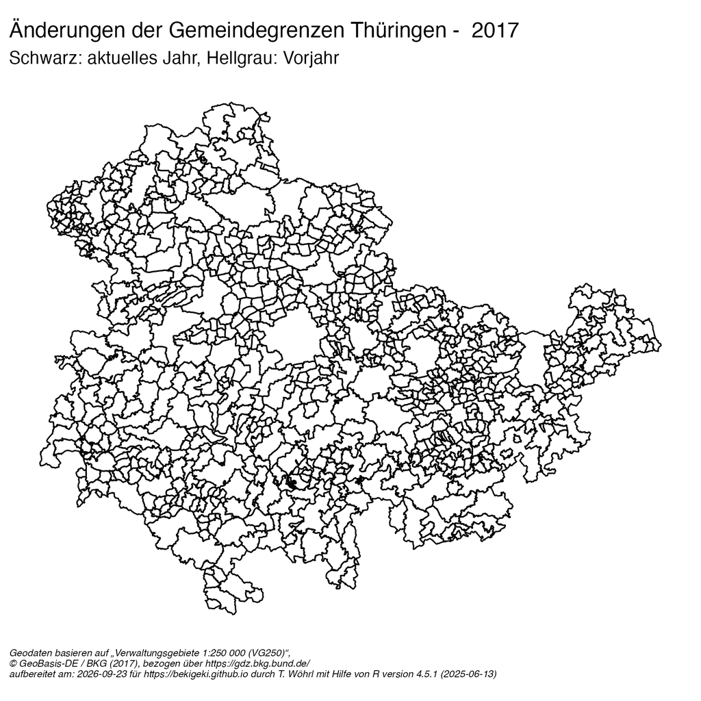

## Transparenzhinweis zum Einsatz von KI-Unterstützung

Für die sprachliche Glättung und Verdichtung einzelner Textpassagen auf dieser Website wurde das KI-gestützte Recherche- und Schreibwerkzeug *Perplexity* verwendet. Alle automatisch erzeugten oder umformulierten Vorschläge wurden inhaltlich geprüft, gegebenenfalls angepasst und redaktionell freigegeben; die fachliche Verantwortung für die Inhalte liegt vollständig bei den Autoren.

## TODO

- Links ggf. zum Glossar
- Hinweise unterschiedlichen Einstiegsmöglichkeiten (Seitenverzeichnis, Abbildungsverzeichnis, inhaltlicher Einstieg)
- Link zur Seite mit Mengenabbildungen (Teilnahme-Konzept)

## Aktualisierungen

- 2026-09-23: GIF Änderung der Verwaltungsgrenzen
- 2026-05-20: Erstellen der Seite